# Exploring the Census Income Dataset

### Profile clusterings with PAM clustering and t-SNE visualization

The k-medoids method is a clustering technique for partitioning the instances of a dataset into k groups. Each cluster is represented by a medoid, which essentially is one data point that represents the whole cluster. This approach is somewhat related to k-means clustering, however, instead of calculating the mean value, the k-medoids method minimizes the average dissimilarity between the medoid and all the other instances within a cluster. Therefore, k-medoid clustering is more robust and less sensitive to noise and outliers.

The method requires the number of clusters to be specified prior to the calculation. An often applied method to determine the optimal number of clusters is the silhouette method, where the largest width refers to the best discriminability of the dataset into clusters.

The most commonly used algorithm for implementing k-medoids is PAM (Partitioning Around Medoids) (Kaufman and Rousseeuw 1990).

The PAM algorithm calculates a matrix of dissimilarity, using the Euclidean distance for numeric variables, the Manhattan distance for categorical variables, or the Gower distance for mixed datasets (numerical and categorical variables).

A common method to visualize datasets with many features is t-SNE (T-Distributed Stochastic Neighboring Entities). This non-linear, probabilistic algorithm can project a high-dimensional dataset into a 2-dimensional map. The method often generates better discriminable clusters than PCA, however a key drawback is that it is much more computationally intensive than PCA.

Therefore, given the large data set and our time constraints, for now, for illustrative purposes, we apply the PAM method to a subset of the data available to illustrate the method’s criteria for choosing the optimal numbers of clusters and to illustrate approaches for visualizing the outputs.

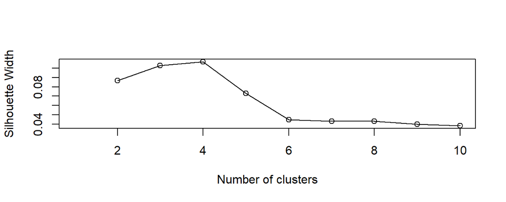

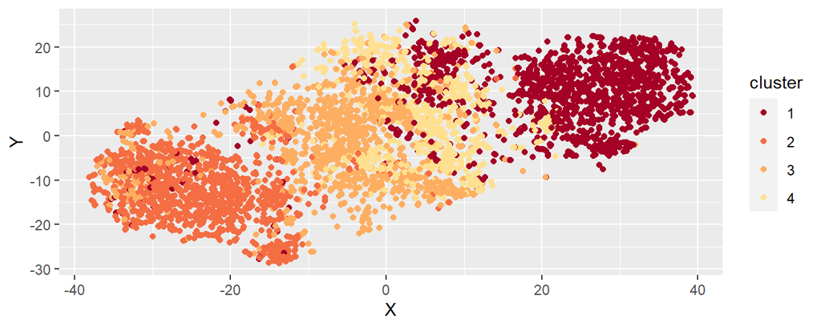

```
## [1] "Clusters analysis"
```

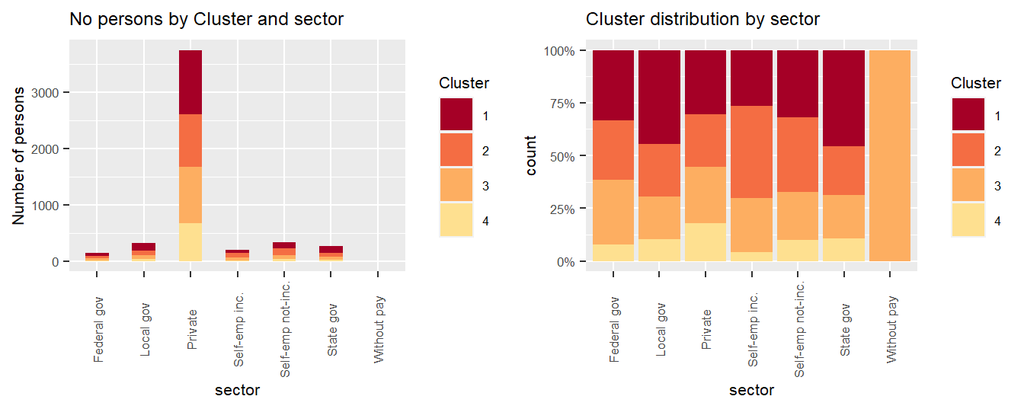

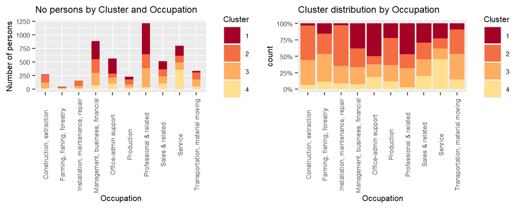

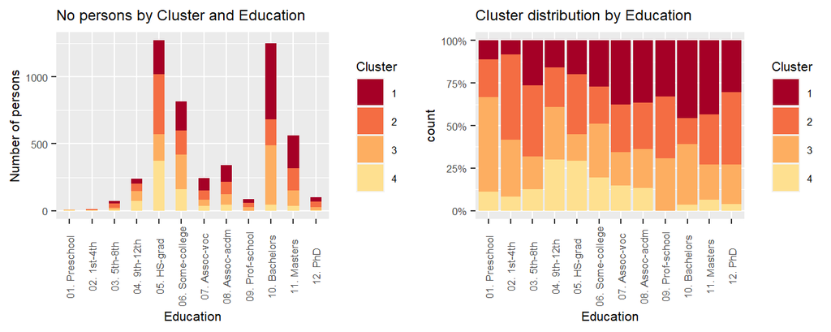

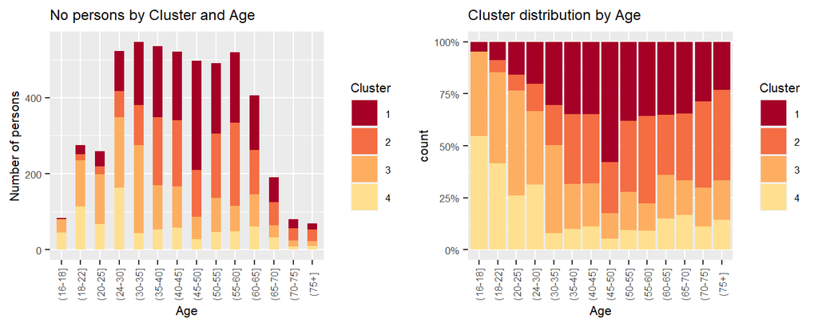

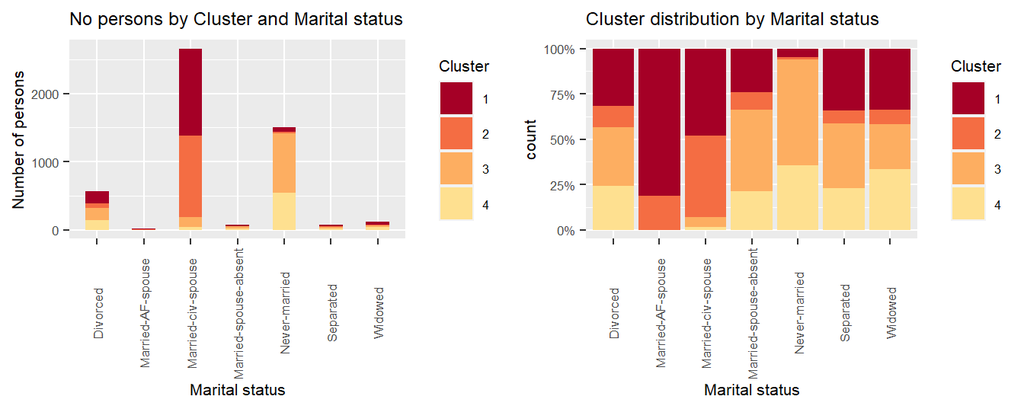

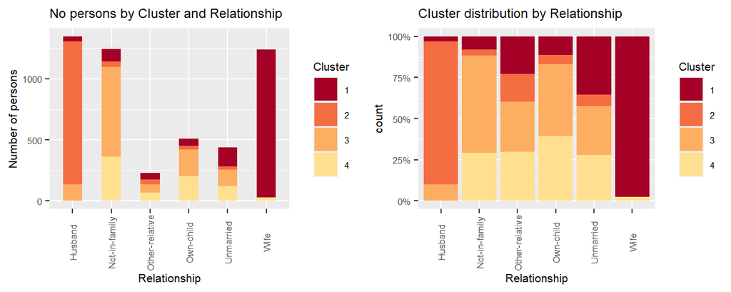

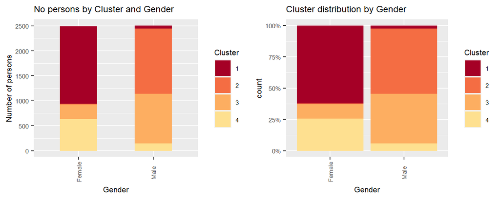

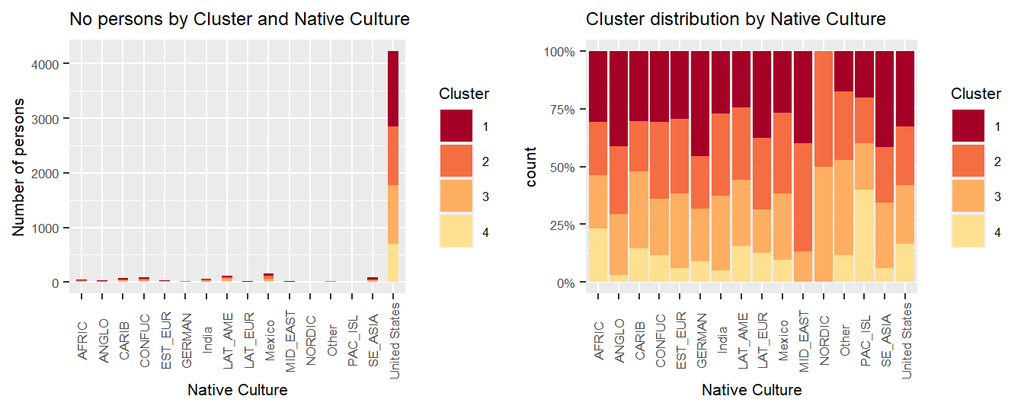

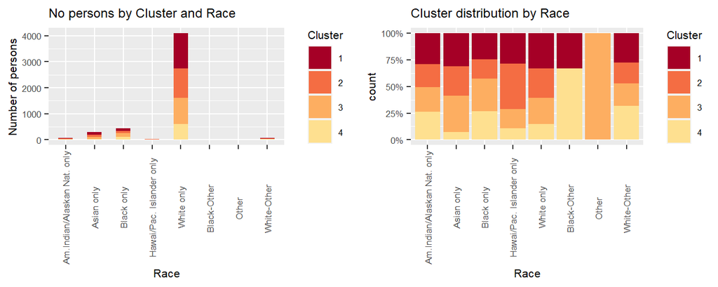

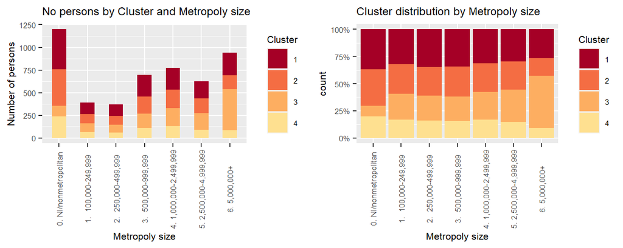

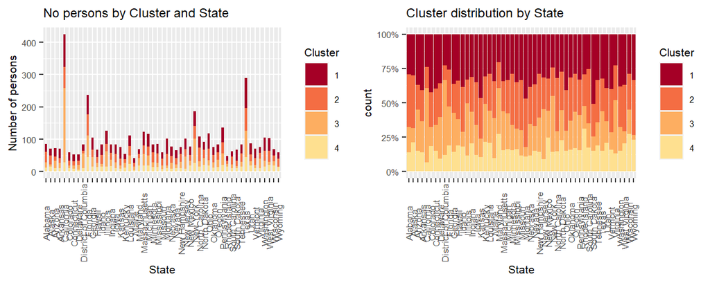

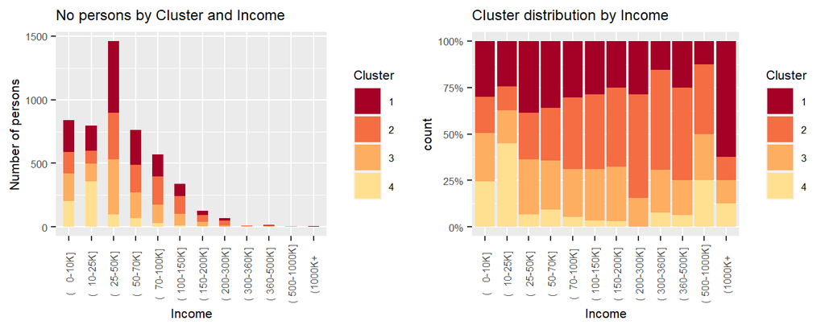

[2 more figures not shown]

#### PAM Clustering Observations

The Silhouette method indicated four as an optimal number of clusters. The following is a brief characterization of each of the clusters:

Cluster 1: The cluster is mostly composed of middle aged (40-50 years old), married females. It contains the majority of instances related to the very high income bracket (>1,000k), as well as high capital gains (>200k). Interestingly, cluster 1 comprises virtually all instances related to a work load of zero hours per week.

Cluster 2: This cluster is mostly composed of self-employed (Inc.), relatively older, and married males. The cluster represents the largest fraction in the income bracket 200k-500k, and the associated persons tend to work more than 40h per week.

Cluster 3: The cluster comprises virtually all instances related to no salary (“without pay”), and represents the largest fraction associated with preschool education. Persons in this cluster tend to be young (<35 years old), single males, and living preferably in larger cities (metropoly size > 5M).

Cluster 4: Persons associated with this cluster tend to be young, non-married, females, with a somewhat lower than average education. The cluster represents the largest fraction in the income bracket 10-25k, and the associated persons tend to work part-time (>0 to 35 hours per week).

### Profile clusterings with Agglomerative Hierarchical Clustering

Hierarchical Clustering Analysis(HAC) is "a method of cluster analysis which seeks to build a hierarchy of clusters. Strategies for hierarchical clustering generally fall into two types:

Agglomerative: This is a “bottom-up” approach: each observation starts in its own cluster, and pairs of clusters are merged as one moves up the hierarchy. Divisive: This is a “top-down” approach: all observations start in one cluster, and splits are performed recursively as one moves down the hierarchy." (Source:https://en.wikipedia.org/wiki/Hierarchical_clustering)

“Hierarchical clustering constructs trees of clusters of objects, in which any two clusters are disjoint, or one includes the other. The cluster of all objects is the root of the tree. Agglomerative algorithms […] require a definition of dissimilarity between clusters; the most common ones are maximum or complete linkage, in which the dissimilarity between two clusters is the maximum of all pairs of dissimilarities between pairs of points in the different clusters; minimum or single linkage or nearest neighbor […] in which the dissimilarity between two clusters is the minimum over all those pairs of dissimilarities; and average linkage in which the dissimilarity between the two clusters is the average, or suitably weighted average, over all those pairs of dissimilarities. Agglomerative algorithms begin with an initial set of singleton clusters consisting of all the objects; proceed by agglomerating the pair of clusters of minimum dissimilarity to obtain a new cluster, removing the two clusters combined from further consideration; and repeat this agglomeration step until a single cluster containing all the observations is obtained. The set of clusters obtained along the way forms a hierarchical clustering.”(source: J.A. Hartigan, 2001, “Statistical Clustering”, International Encyclopedia of the Social & Behavioral Sciences,)

“If the number of elements to be clustered is represented by n and the number of clusters is represented by k, then the time complexity of hierarchical algorithms is of the order (kn^2).”(source: S.G. Roy, A. Chakrabarti, “A novel graph clustering algorithm based on discrete-time quantum random walk”, Quantum Inspired Computational Intelligence, 2017)

We will employ the Agglomerative Hierarchical Clustering with complete method to determine the optimum number of clusters. to determine the best number of clusters we use the elbow method and compare it with the silhouette method.

Given the large datasest and our time constraints, for now, for illustrative purposes, we apply the HAC method to a subset of the data available to illustrate the method’s criteria for choosing the optimal numbers of clusters and to illustrate approaches for visualizing the outputs.

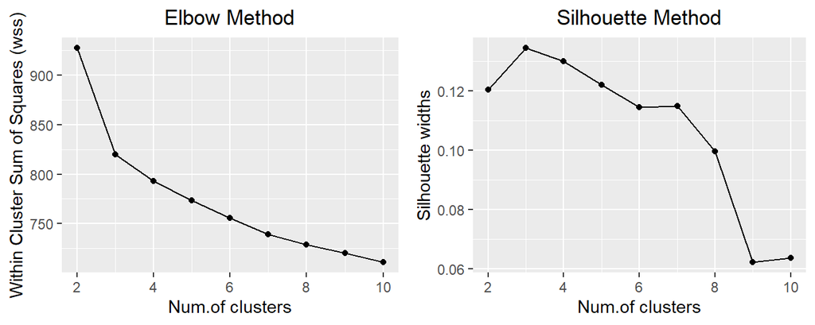

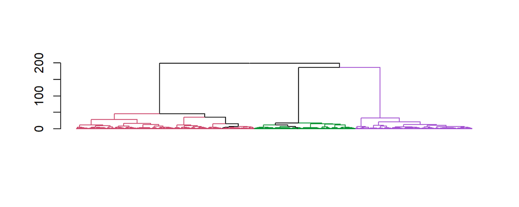

Both Elbow and Silhouette method indicated that the optimal number of cluster is 3. The dendrogram also shows that 3 is the optimum value of k. Having selected k = 3, let’s look at each cluster by doing a summary plots.

#### Visualizing the clusters

Let’s visualize the clusters using t-SNE (t-distributed Stochastic Neighbor Embedding).

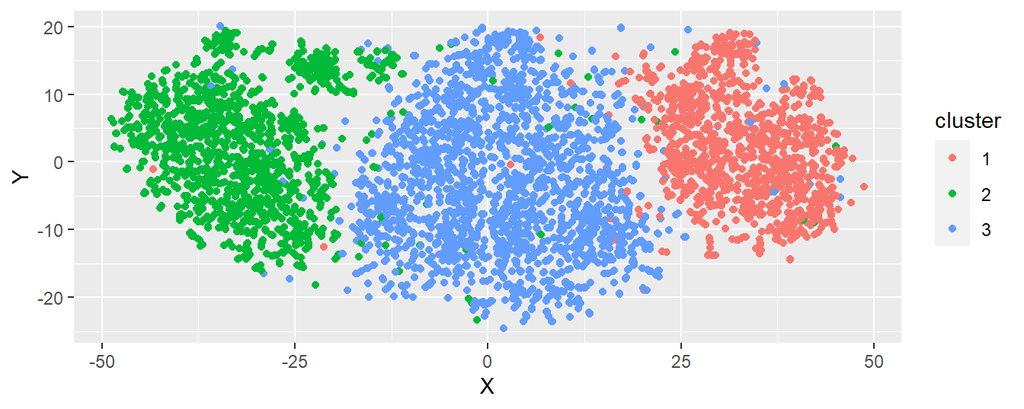

```
## [1] "Clusters analysis"
```

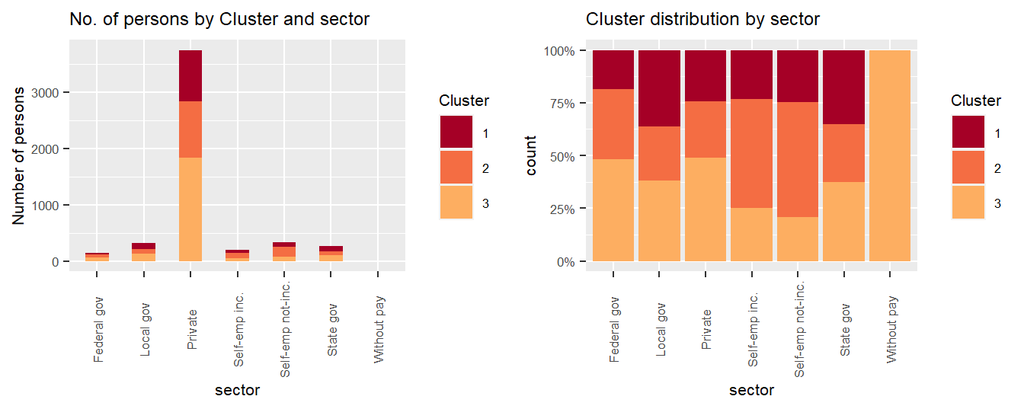

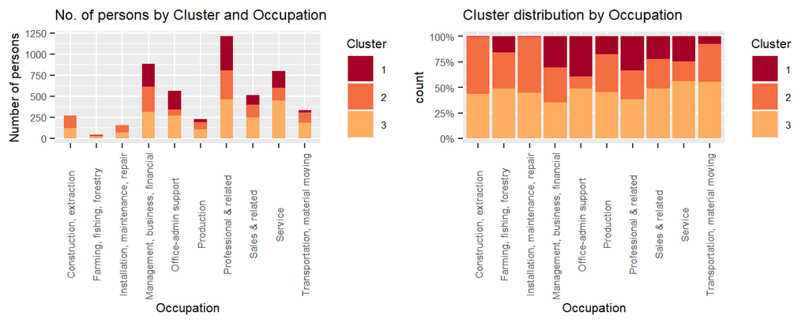

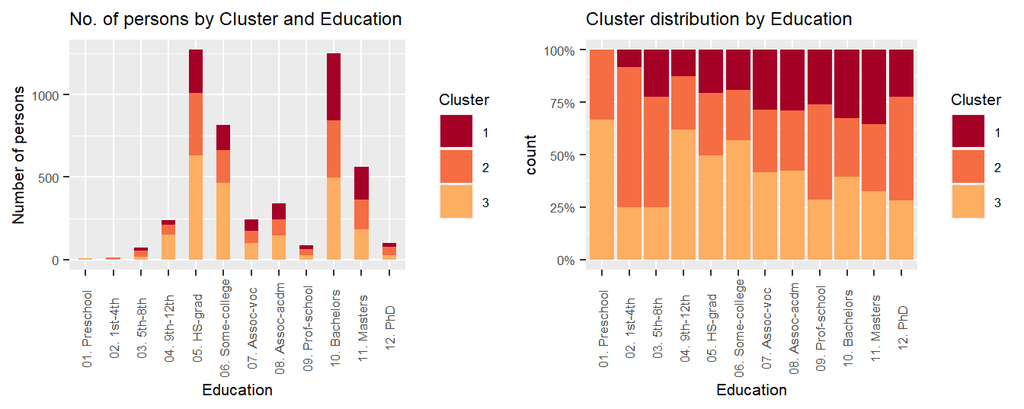

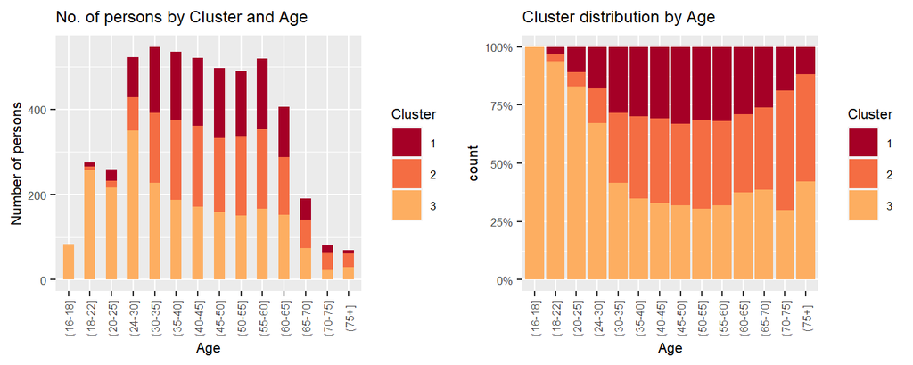

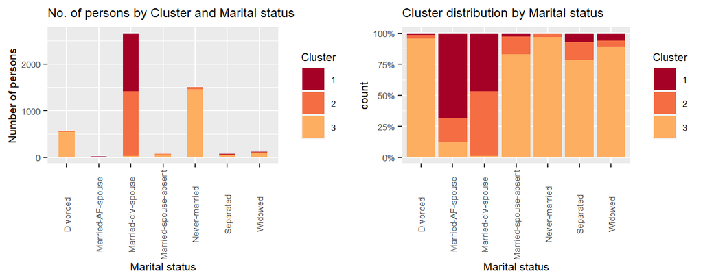

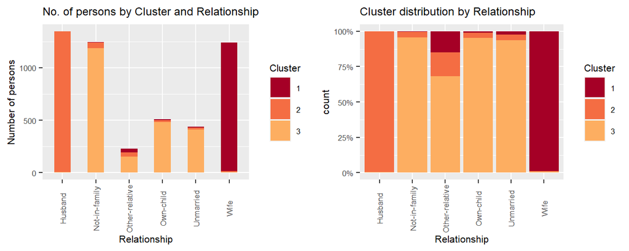

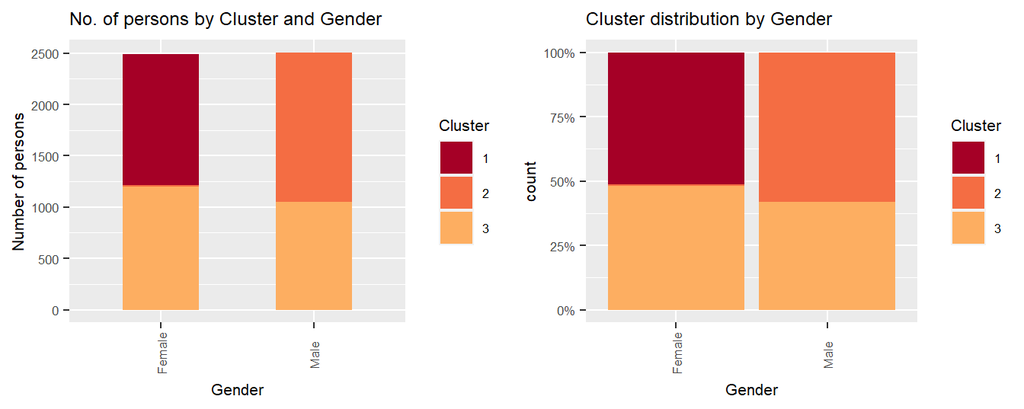

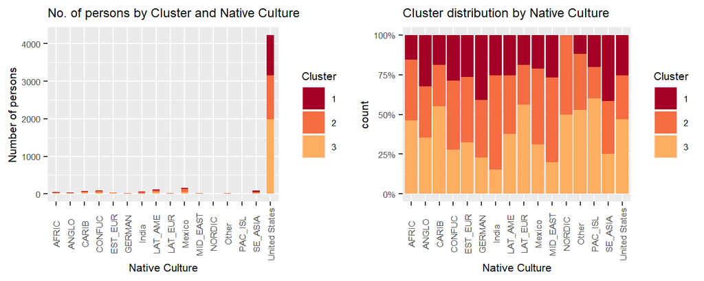

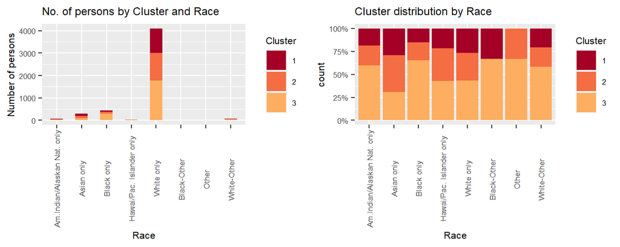

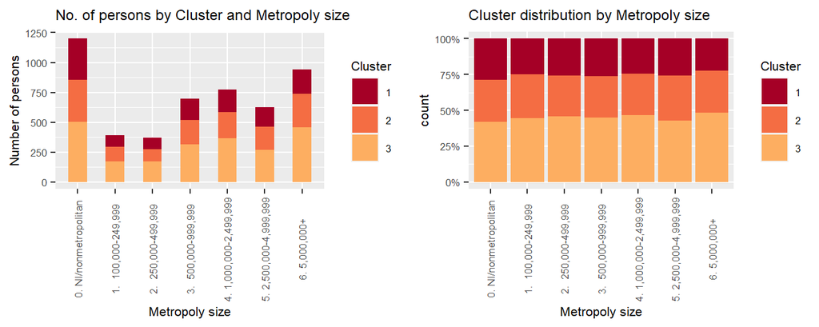

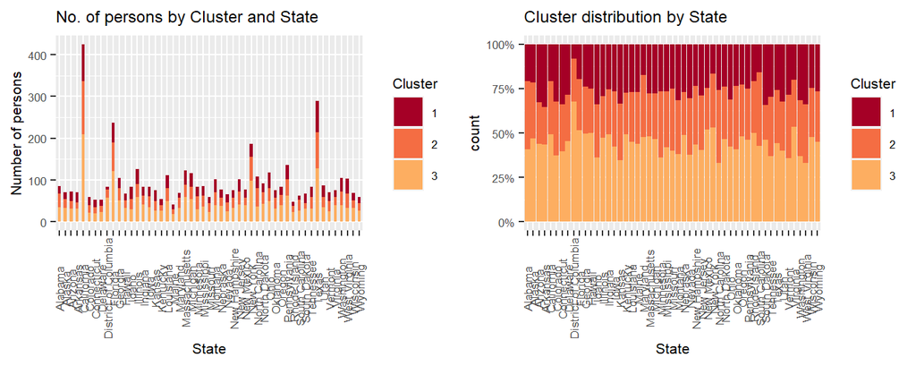

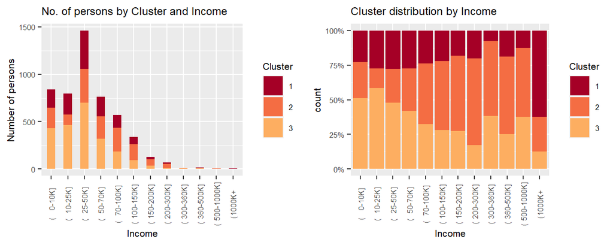

[2 more figures not shown]

#### Agglomerative Hierarchical Cluster Observations

Cluster 1: Mostly composed of highly educated, middle aged, married female. Mostly are Professional and/or in Management, Business, Financial or Office administration. A higher percentage of cluster 1 are mid-income. But it should be noted that more than 50% of 1M+ earners are members of Cluster 1.

Cluster 2: Mostly composed of skilled and highly educated, middle aged and older Male who are working in various occupation. A bigger percentage are working in Construction, Installation, Maintenance, Repair and Transportation. A high percentage of Cluster 2 members earn 70K and higher, up to 1M+.

Cluster 3: This cluster is divided between Male and Female. A high percentage of the members are young, single/divorced and widowed. A higher percentage has an Associate Degree and less. A higher percentage are mid-income to low income but a few earns as high as 1M+.

## Ethics points

The US census data covers a set of personal characteristics such as gender, as well as racial and cultural minorities.

One can observe in the data that certain categories can have significantly different profile with respect to income and education.

As such, if data were used in customer segmentation based on income and education, particular attention should be given to avoid unethical systematic adverse selection of certain groups.

# Model Deployment

The model and the shiny app developed in this project can be useful to the retail bank in that it provides insight into the structure of census data, and it may be suitable for grouping potential customers into clusters that can be designated to certain types of credit card offers.

The results of the three applied clustering methods are to some extent different. Whereas the optimum number of clusters for k-means and k-medoids were four, the optimum number of clusters for hierarchical clustering was three. Based on the t-SNE visualization of the results, hierarchical clustering seems to be able to discriminate clusters to the largest extent. Considering the differences of the results, the uncertainty associated with the grouping of the instances into clusters, and the potential ethical issues involved, the retail bank may carefully consider how these results may be used for their purposes.

K-means was implemented into the shiny app for two reasons:i) it is not computationally intensive and ii)the clustering obtained is reasonable and aligned with the credit card concept and with what we observed in the data.

The shiny app associated with our model illustrates how a new, potential customer may fit into one of the clusters, and how far the distance is between this customer and the other clusters. Furthermore, the app visualizes how each of the individual clusters is characterized, and what are the most distinguishing factors.

If time would allow it, the model(s) could be further improved. For example, the clustering methods could be fine-tuned by implementing more feature engineering. Also, computationally more intensive methods such as t-SNE could be modified by applying a different dimensionality reduction method prior to applying t-SNE. Lastly, different features from the publicly available census dataset could be included and tested in terms of improving cluster generation.

Link to the shiny app: https://robin-mathew.shinyapps.io/CustomerSegmentationProject/. Please allow 10 to 15 seconds to load.

## References

Mensah Yaw M., Hsiao-Yin Chen, 2013,“Global Clustering of Countries by Culture – An Extension of the GLOBE Study” https://papers.ssrn.com/sol3/papers.cfm?abstract_id=2189904

Kohav Ron , 1996, “Scaling Up the Accuracy of Naive-Bayes Classifiers: a Decision-Tree Hybrid”, Proceedings of the Second International Conference on Knowledge Discovery and Data Mining,

Kaufman, Leonard, and Peter Rousseeuw. 1990. Finding Groups in Data: An Introduction to Cluster Analysis.